# Separating Spam from Ham

Quang Duong

2017-07-17

Nearly every email user has at some point encountered a “spam” email, which is an unsolicited message often advertising a product, containing links to malware, or attempting to scam the recipient. Roughly 80-90% of more than 100 billion emails sent each day are spam emails, most being sent from botnets of malware-infected computers. The remainder of emails are called “ham” emails.

As a result of the huge number of spam emails being sent across the Internet each day, most email providers offer a spam filter that automatically flags likely spam messages and separates them from the ham. Though these filters use a number of techniques (e.g. looking up the sender in a so-called “Blackhole List” that contains IP addresses of likely spammers), most rely heavily on the analysis of the contents of an email via text analytics.

In this homework problem, we will build and evaluate a spam filter using a publicly available dataset first described in the 2006 conference paper “Spam Filtering with Naive Bayes – Which Naive Bayes?” by V. Metsis, I. Androutsopoulos, and G. Paliouras. The “ham” messages in this dataset come from the inbox of former Enron Managing Director for Research Vincent Kaminski, one of the inboxes in the Enron Corpus. One source of spam messages in this dataset is the SpamAssassin corpus, which contains hand-labeled spam messages contributed by Internet users. The remaining spam was collected by Project Honey Pot, a project that collects spam messages and identifies spammers by publishing email address that humans would know not to contact but that bots might target with spam. The full dataset we will use was constructed as roughly a 75/25 mix of the ham and spam messages.

The dataset contains just two fields:

*text*: The text of the email. *spam*: A binary variable indicating if the email was spam.

## Loading the Dataset

Begin by loading the dataset emails.csv into a data frame called emails. Remember to pass the stringsAsFactors=FALSE option when loading the data.

How many emails are in the dataset?

```r
emails <- read.csv("emails.csv", stringsAsFactors = FALSE)
str(emails)
```

```
'data.frame':   5728 obs. of  2 variables:
 $ text: chr  "Subject: naturally irresistible your corporate identity  lt is really hard to recollect a company : the  market"| __truncated__ "Subject: the stock trading gunslinger  fanny is merrill but muzo not colza attainder and penultimate like esmar"| __truncated__ "Subject: unbelievable new h…
 $ spam: int  1 1 1 1 1 1 1 1 1 1 ...
```

How many of the emails are spam?

```r
table(emails$spam)
```

```
   0    1
4360 1368
```

Which word appears at the beginning of every email in the dataset? Respond as a lower-case word with punctuation removed.

```r
emails$text[2]
```

```
[1] "Subject: the stock trading gunslinger  fanny is merrill but muzo not colza attainder and penultimate like esmark perspicuous ramble is segovia not group try slung kansas tanzania yes chameleon or continuant clothesman no  libretto is chesapeake but tight not waterway herald and hawthorn like ch…
```

The nchar() function counts the number of characters in a piece of text. How many characters are in the longest email in the dataset (where longest is measured in terms of the maximum number of characters)?

```r
max(nchar(emails$text))
```

```
[1] 43952
```

Which row contains the shortest email in the dataset? (Just like in the previous problem, shortest is measured in terms of the fewest number of characters.)

```r
which.min(nchar(emails$text))
```

```
[1] 1992
```

## Preparing the Corpus

Follow the standard steps to build and pre-process the corpus:

1. Build a new corpus variable called corpus.
2. Using tm_map, convert the text to lowercase.
3. Using tm_map, remove all punctuation from the corpus.
4. Using tm_map, remove all English stopwords from the corpus.
5. Using tm_map, stem the words in the corpus.
6. Build a document term matrix from the corpus, called dtm.

```r
library(tm)
library(SnowballC)
corpus <- VCorpus(VectorSource(emails$text))
corpus <- tm_map(corpus, content_transformer(tolower))
corpus <- tm_map(corpus, content_transformer(removePunctuation))
corpus <- tm_map(corpus, removeWords, stopwords("english"))
corpus <- tm_map(corpus, stemDocument)
dtm <- DocumentTermMatrix(corpus)
```

How many terms are in dtm?

```r
dtm
```

```
<<DocumentTermMatrix (documents: 5728, terms: 28687)>>
Non-/sparse entries: 481719/163837417
Sparsity           : 100%
Maximal term length: 24
Weighting          : term frequency (tf)
```

To obtain a more reasonable number of terms, limit dtm to contain terms appearing in at least 5% of documents, and store this result as spdtm (don’t overwrite dtm, because we will use it in a later step of this homework). How many terms are in spdtm?

```r
spdtm <- removeSparseTerms(dtm, sparse = 0.95)
spdtm
```

```
<<DocumentTermMatrix (documents: 5728, terms: 330)>>
Non-/sparse entries: 213551/1676689
Sparsity           : 89%
Maximal term length: 10
Weighting          : term frequency (tf)
```

Build a data frame called emailsSparse from spdtm, and use the make.names function to make the variable names of emailsSparse valid.

colSums() is an R function that returns the sum of values for each variable in our data frame. Our data frame contains the number of times each word stem (columns) appeared in each email (rows). Therefore, colSums(emailsSparse) returns the number of times a word stem appeared across all the emails in the dataset. What is the word stem that shows up most frequently across all the emails in the dataset?

```r
emailsSparse <- as.data.frame(as.matrix(spdtm))
colnames(emailsSparse) <- make.names(colnames(emailsSparse))
tail(sort(colSums(emailsSparse)))
```

```
    hou    will    vinc subject     ect   enron
   5577    8252    8532   10202   11427   13388
```

Add a variable called “spam” to emailsSparse containing the email spam labels. You can do this by copying over the “spam” variable from the original data frame (remember how we did this in the Twitter lecture).

How many word stems appear at least 5000 times in the ham emails in the dataset?

```r
emailsSparse$spam <- emails$spam
wordsHam <- colSums(subset(emailsSparse, emailsSparse$spam==0))
sort(wordsHam)
```

```
      spam       life      remov      money      onlin    without
         0         80        103        114        173        191
    websit      click    special       wish      repli        buy
       194        217        226        229        239        243
       net       link     immedi       done       mean     design
       243        247        249        254        259        261
       lot     effect       info     either       read      write
       268        270        273        279        279        286
      line      begin      sorri    success     involv      creat
       289        291        293        293        294        299
   softwar     better     vkamin        say       keep      bring
       299        301        301        305        306        311
    believ       full    increas     realli    mention    thought
       313        317        320        324        325        325
      idea     invest      secur     specif      sever     experi
       327        327        337        338        340        346
     thing      allow      check        due       type      happi
       347        348        351        351        352        354
    return     expect      short     effort       open   internet
       355        356        357        358        360        361
    sincer     public     recent      anoth    alreadi       home
       361        364        368        369        372        375
      made    respond      given        etc        put     within
       380        382        383        385        385        386
     place      right    version      hello       sure       area
       388        390        390        395        396        397
       run     arrang    account       join       hour      locat
       398        399        401        403        404        406
    togeth      engin     import        per     corpor       high
       406        411        411        412        414        416
    result       hear      final       deal     applic       even
       418        420        422        423        428        429
       web     custom       soon       long       sinc      futur
       430        433        435        436        439        440
    member       X000      event        don       part       feel
       446        447        447        450        450        453
   tuesday  wednesday      still       unit       site       X853
       454        456        457        457        458        461
   continu understand    resourc     robert    analysi       form
       464        464        466        466        468        468
```

[output cut: 57 more lines]

```
      1577       1604       1607       1620       1643       1687
   develop        get        new        use        let     regard
      1691       1768       1777       1784       1856       1859
    inform       need      power        may       like       risk
      1883       1890       1972       1976       1980       2097
    energi     market      model      price       work      manag
      2124       2150       2170       2191       2293       2334
      know      group       meet       time   research    forward
      2345       2474       2544       2552       2752       2952
     X2001        can      thank        com      pleas   kaminski
      3060       3426       3558       4444       4494       4801
     X2000        hou       will       vinc    subject        ect
      4935       5569       6802       8531       8625      11417
     enron
     13388
```

How many word stems appear at least 1000 times in the spam emails in the dataset?

```r
wordsSpam <- colSums(subset(emailsSparse, emailsSparse$spam==1))
sort(wordsSpam)
```

```
      X713   crenshaw      enron     gibner   kaminski    stinson
         0          0          0          0          0          0
    vkamin       X853       vinc        doc      kevin    shirley
         0          1          1          2          2          2
     deriv      april    houston      resum        edu     friday
         3          5          5          5          7          7
       hou  wednesday        ect     arrang  interview     attend
         8          8         10         11         13         15
    london     robert    student    schedul   thursday     monday
        15         16         16         17         17         19
      john    tuesday     attach    suggest    appreci       mark
        20         20         21         21         23         25
     begin    comment    analysi      X2001      model       hope
        26         26         27         29         29         30
   mention      X2000     togeth     confer      invit    univers
        30         32         32         33         33         34
    financ       talk     either        run       morn      shall
        35         38         39         39         40         40
     happi    thought     depart    confirm    respond     school
        42         42         46         47         48         48
      corp        etc       hear      howev      sorri       idea
        49         49         49         49         50         51
    energi    discuss       open     option       soon understand
        55         56         56         56         57         57
     cours     experi     associ      point      bring   director
        59         59         62         62         63         65
  particip      anoth       join      still      final   research
        65         66         66         66         68         68
      case        set     specif      given       juli    problem
        69         69         69         70         71         73
       put    alreadi        ask        abl       deal        fax
        73         74         74         75         75         75
      book       team       issu      locat       meet      updat
        76         76         79         79         79         79
       lot     sincer     better      short       sinc       done
        80         80         82         82         82         83
  question     recent    possibl   contract        end       move
        83         83         84         85         85         86
      data      might    continu       note       feel    resourc
        87         87         88         88         90         90
```

[output cut: 57 more lines]

```
       426        428        435        438        440        445
      site    address        may       list      price        new
       455        461        489        503        503        504
    websit     report      secur       just      offer     invest
       506        507        520        524        528        540
     order        use      click       X000        now        one
       541        546        552        560        575        592
      time       http     market       make       free      pleas
       593        600        600        603        606        619
     money        get     receiv     inform        can      email
       662        694        727        818        831        865
      busi       mail        com    compani       spam       will
       897        917        999       1065       1368       1450
   subject
      1577
```

Several of the most common word stems from the ham documents, such as “enron”, “hou” (short for Houston), “vinc” (the word stem of “Vince”) and “kaminski”, are likely specific to Vincent Kaminski’s inbox. What does this mean about the applicability of the text analytics models we will train for the spam filtering problem?

The models we build are personalized, and would need to be further tested before being used as a spam filter for another person.

## Building Machine Learning Models

First, convert the dependent variable to a factor.

Next, set the random seed to 123 and use the sample.split function to split emailsSparse 70/30 into a training set called “train” and a testing set called “test”. Make sure to perform this step on emailsSparse instead of emails.

Using the training set, train the following three machine learning models. The models should predict the dependent variable “spam”, using all other available variables as independent variables. Please be patient, as these models may take a few minutes to train.

1. A logistic regression model called spamLog. You may see a warning message here - we’ll discuss this more later.
2. A CART model called spamCART, using the default parameters to train the model (don’t worry about adding minbucket or cp). Remember to add the argument method=“class” since this is a binary classification problem.
3. A random forest model called spamRF, using the default parameters to train the model (don’t worry about specifying ntree or nodesize). Directly before training the random forest model, set the random seed to 123 (even though we’ve already done this earlier in the problem, it’s important to set the seed right before training the model so we all obtain the same results. Keep in mind though that on certain operating systems, your results might still be slightly different).

For each model, obtain the predicted spam probabilities for the training set. Be careful to obtain probabilities instead of predicted classes, because we will be using these values to compute training set AUC values. Recall that you can obtain probabilities for CART models by not passing any type parameter to the predict() function, and you can obtain probabilities from a random forest by adding the argument type=“prob”. For CART and random forest, you need to select the second column of the output of the predict() function, corresponding to the probability of a message being spam.

You may have noticed that training the logistic regression model yielded the messages “algorithm did not converge” and “fitted probabilities numerically 0 or 1 occurred”. Both of these messages often indicate overfitting and the first indicates particularly severe overfitting, often to the point that the training set observations are fit perfectly by the model. Let’s investigate the predicted probabilities from the logistic regression model.

How many of the training set predicted probabilities from spamLog are less than 0.00001?

```r
emailsSparse$spam <- as.factor(emailsSparse$spam)
set.seed(123)
library(caTools)
spl <- sample.split(emailsSparse$spam, SplitRatio = 0.7)
train <- subset(emailsSparse, spl == TRUE)
test <- subset(emailsSparse, spl == FALSE)
spamLog <- glm(spam ~ ., data = train, family = "binomial")
library(rpart)
library(rpart.plot)
spamCART <- rpart(spam ~ ., data = train, method = "class")
library(randomForest)
set.seed(123)
spamRF <- randomForest(spam ~ ., data = train)
predTrainLog <- predict(spamLog)
sum(predTrainLog < 0.00001)
sum(predTrainLog > 0.99999)
sum(predTrainLog < 0.99999 & predTrainLog > 0.00001)
```

```
[1] 3056
[1] 954
[1] 0
```

How many variables are labeled as significant (at the p=0.05 level) in the logistic regression summary output?

```r
summary(spamLog)
```

```
Call:
glm(formula = spam ~ ., family = "binomial", data = train)

Deviance Residuals:
   Min      1Q  Median      3Q     Max
-1.011   0.000   0.000   0.000   1.354

Coefficients:
              Estimate Std. Error z value Pr(>|z|)
(Intercept) -3.082e+01  1.055e+04  -0.003    0.998
X000         1.474e+01  1.058e+04   0.001    0.999
X2000       -3.631e+01  1.556e+04  -0.002    0.998
X2001       -3.215e+01  1.318e+04  -0.002    0.998
X713        -2.427e+01  2.914e+04  -0.001    0.999
X853        -1.212e+00  5.942e+04   0.000    1.000
abl         -2.049e+00  2.088e+04   0.000    1.000
access      -1.480e+01  1.335e+04  -0.001    0.999
account      2.488e+01  8.165e+03   0.003    0.998
addit        1.463e+00  2.703e+04   0.000    1.000
address     -4.613e+00  1.113e+04   0.000    1.000
allow        1.899e+01  6.436e+03   0.003    0.998
alreadi     -2.407e+01  3.319e+04  -0.001    0.999
also         2.990e+01  1.378e+04   0.002    0.998
analysi     -2.405e+01  3.860e+04  -0.001    1.000
anoth       -8.744e+00  2.032e+04   0.000    1.000
applic      -2.649e+00  1.674e+04   0.000    1.000
appreci     -2.145e+01  2.762e+04  -0.001    0.999
approv      -1.302e+00  1.589e+04   0.000    1.000
april       -2.620e+01  2.208e+04  -0.001    0.999
area         2.041e+01  2.266e+04   0.001    0.999
arrang       1.069e+01  2.135e+04   0.001    1.000
ask         -7.746e+00  1.976e+04   0.000    1.000
assist      -1.128e+01  2.490e+04   0.000    1.000
associ       9.049e+00  1.909e+04   0.000    1.000
attach      -1.037e+01  1.534e+04  -0.001    0.999
attend      -3.451e+01  3.257e+04  -0.001    0.999
avail        8.651e+00  1.709e+04   0.001    1.000
back        -1.323e+01  2.272e+04  -0.001    1.000
base        -1.354e+01  2.122e+04  -0.001    0.999
begin        2.228e+01  2.973e+04   0.001    0.999
```

[output cut: 293 more lines]

```
wish         1.173e+01  3.175e+04   0.000    1.000
within       2.900e+01  2.163e+04   0.001    0.999
without      1.942e+01  1.763e+04   0.001    0.999
work        -1.099e+01  1.160e+04  -0.001    0.999
write        4.406e+01  2.825e+04   0.002    0.999
www         -7.867e+00  2.224e+04   0.000    1.000
year        -1.010e+01  1.039e+04  -0.001    0.999

(Dispersion parameter for binomial family taken to be 1)

    Null deviance: 4409.49  on 4009  degrees of freedom
Residual deviance:   13.46  on 3679  degrees of freedom
AIC: 675.46

Number of Fisher Scoring iterations: 25
```

How many of the word stems “enron”, “hou”, “vinc”, and “kaminski” appear in the CART tree? Recall that we suspect these word stems are specific to Vincent Kaminski and might affect the generalizability of a spam filter built with his ham data.

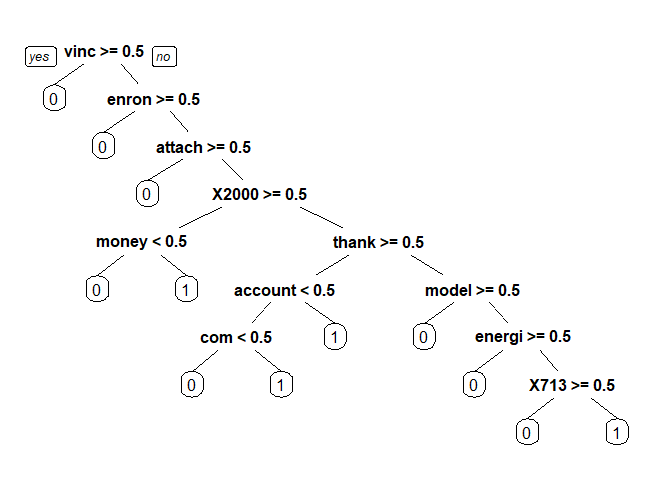

```r
prp(spamCART)
```

What is the training set accuracy of spamLog, using a threshold of 0.5 for predictions?

```r
table(train$spam, predTrainLog >= 0.5)
(3052+954)/(3052+954+4)
```

```
    FALSE TRUE
  0  3052    0
  1     4  954
[1] 0.9990025
```

What is the training set AUC of spamLog?

```r
library(ROCR)
as.numeric(performance(prediction(predTrainLog, train$spam), "auc")@y.values)
```

```
[1] 0.9999959
```

What is the training set accuracy of spamCART, using a threshold of 0.5 for predictions? (Remember that if you used the type=“class” argument when making predictions, you automatically used a threshold of 0.5. If you did not add in the type argument to the predict function, the probabilities are in the second column of the predict output.)

```r
predTrainCART <- predict(spamCART)
table(train$spam, predTrainCART[,2]>=0.5)
(2885+894)/(2885+894+167+64)
```

```
    FALSE TRUE
  0  2885  167
  1    64  894
[1] 0.942394
```

What is the training set AUC of spamCART? (Remember that you have to pass the prediction function predicted probabilities, so don’t include the type argument when making predictions for your CART model.)

```r
as.numeric(performance(prediction(predTrainCART[,2], train$spam), "auc")@y.values)
```

```
[1] 0.9696044
```

What is the training set accuracy of spamRF, using a threshold of 0.5 for predictions? (Remember that your answer might not match ours exactly, due to random behavior in the random forest algorithm on different operating systems.)

```r
predTrainRF <- predict(spamRF, type = "prob")
table(train$spam, predTrainRF[,2]>=0.5)
(3013+914)/(3013+914+39+44)
```

```
    FALSE TRUE
  0  3013   39
  1    44  914
[1] 0.9793017
```

What is the training set AUC of spamRF?

```r
as.numeric(performance(prediction(predTrainRF[,2], train$spam), "auc")@y.values)
```

```
[1] 0.9979116
```

In terms of both accuracy and AUC, logistic regression is nearly perfect and outperforms the other two models.

Obtain predicted probabilities for the testing set for each of the models, again ensuring that probabilities instead of classes are obtained.

What is the testing set accuracy of spamLog, using a threshold of 0.5 for predictions?

```r
predLog <- predict(spamLog, newdata = test, type = "response")
table(test$spam, predLog >= 0.5)
(1257+376)/(1257+376+51+34)
```

```
    FALSE TRUE
  0  1257   51
  1    34  376
[1] 0.9505239
```

What is the testing set AUC of spamLog?

```r
as.numeric(performance(prediction(predLog, test$spam), "auc")@y.values)
```

```
[1] 0.9627517
```

What is the testing set accuracy of spamCART, using a threshold of 0.5 for predictions?

```r
predCART <- predict(spamCART, newdata = test)
table(test$spam, predCART[,2]>=0.5)
(1228+386)/(1228+386+80+24)
```

```
    FALSE TRUE
  0  1228   80
  1    24  386
[1] 0.9394645
```

What is the testing set AUC of spamCART?

```r
as.numeric(performance(prediction(predCART[,2], test$spam), "auc")@y.values)
```

```
[1] 0.963176
```

What is the testing set accuracy of spamRF, using a threshold of 0.5 for predictions?

```r
predRF <- predict(spamRF, newdata = test, type = "prob")
table(test$spam, predRF[,2]>=0.5)
(1290+386)/(1290+386+18+24)
```

```
    FALSE TRUE
  0  1290   18
  1    24  386
[1] 0.975553
```

What is the testing set AUC of spamRF?

```r
as.numeric(performance(prediction(predRF[,2], test$spam), "auc")@y.values)
```

```
[1] 0.9975656
```

## Integrating Word Count Information

While we have thus far mostly dealt with frequencies of specific words in our analysis, we can extract other information from text. The last two sections of this problem will deal with two other types of information we can extract.

First, we will use the number of words in the each email as an independent variable. We can use the original document term matrix called dtm for this task. The document term matrix has documents (in this case, emails) as its rows, terms (in this case word stems) as its columns, and frequencies as its values. As a result, the sum of all the elements in a row of the document term matrix is equal to the number of terms present in the document corresponding to the row. Obtain the word counts for each email with the command:

```r
wordCount <- rowSums(as.matrix(dtm))
```

What would have occurred if we had instead created wordCount using spdtm instead of dtm?

spdtm has had sparse terms removed, which means we have removed some of the columns but none of the rows from dtm. This means rowSums will still return a sum for each row (one for each email), but it will not have counted the frequencies of any uncommon words in the dataset. As a result, wordCount will only count some of the words.

Use the hist() function to plot the distribution of wordCount in the dataset. What best describes the distribution of the data?

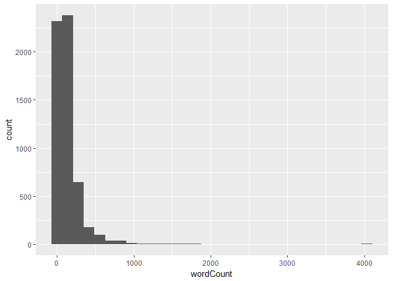

```r
library(ggplot2)
ggplot()+geom_histogram(aes(wordCount))
```

The data is skew right – there are a large number of small wordCount values and a small number of large values.

Now, use the hist() function to plot the distribution of log(wordCount) in the dataset. What best describes the distribution of the data?

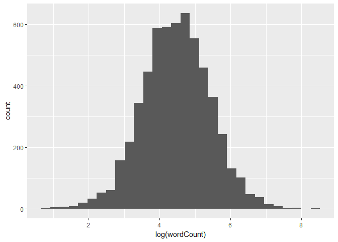

```r
ggplot() + geom_histogram(aes(log(wordCount)))
```

Create a variable called logWordCount in emailsSparse that is equal to log(wordCount). Use the boxplot() command to plot logWordCount against whether a message is spam. Which of the following best describes the box plot?

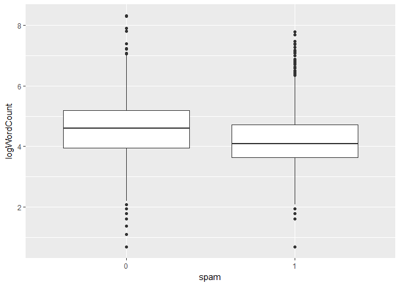

```r
emailsSparse$logWordCount <- log(wordCount)
ggplot(emailsSparse) + geom_boxplot(aes(spam, logWordCount))
```

logWordCount is slightly smaller in spam messages than in ham messages

Because logWordCount differs between spam and ham messages, we hypothesize that it might be useful in predicting whether an email is spam. Take the following steps:

1. Use the same sample.split output you obtained earlier (do not re-run sample.split) to split emailsSparse into a training and testing set, which you should call train2 and test2.
2. Use train2 to train a CART tree with the default parameters, saving the model to the variable spam2CART.
3. Use train2 to train a random forest with the default parameters, saving the model to the variable spam2RF. Again, set the random seed to 123 directly before training spam2RF.

Was the new variable used in the new CART tree spam2CART?

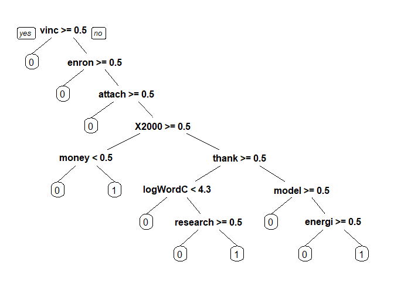

```r
train2 <- subset(emailsSparse, spl == TRUE)
test2 <- subset(emailsSparse, spl == FALSE)
spam2CART <- rpart(spam ~ ., data = train2)
set.seed(123)
spam2RF <- randomForest(spam ~., data = train2)
prp(spam2CART)
```

Perform test-set predictions using the new CART and random forest models.

What is the test-set accuracy of spam2CART, using threshold 0.5 for predicting an email is spam?

```r
predCART2 <- predict(spam2CART, newdata = test2)
table(test2$spam, predCART2[,2]>=0.5)
(1214+384)/(1214+384+94+26)
```

```
    FALSE TRUE
  0  1214   94
  1    26  384
[1] 0.9301513
```

What is the test-set AUC of spam2CART?

```r
as.numeric(performance(prediction(predCART2[,2], test$spam), "auc")@y.values)
```

```
[1] 0.9582438
```

What is the test-set accuracy of spam2RF, using a threshold of 0.5 for predicting if an email is spam? (Remember that you might get a different accuracy than us even if you set the seed, due to the random behavior of randomForest on some operating systems.)

```r
predRF2 <- predict(spam2RF, newdata = test2, type = "prob")
table(test2$spam, predRF2[,2]>=0.5)
(1296+383)/(1296+383+27+12)
```

```
    FALSE TRUE
  0  1296   12
  1    27  383
[1] 0.9772992
```

What is the test-set AUC of spam2RF? (Remember that you might get a different AUC than us even if you set the seed when building your model, due to the random behavior of randomForest on some operating systems.)

```r
as.numeric(performance(prediction(predRF2[,2], test$spam), "auc")@y.values)
```

```
[1] 0.9980905
```

## Using n-grams

Another source of information that might be extracted from text is the frequency of various n-grams. An n-gram is a sequence of n consecutive words in the document. For instance, for the document “Text analytics rocks!”, which we would preprocess to “text analyt rock”, the 1-grams are “text”, “analyt”, and “rock”, the 2-grams are “text analyt” and “analyt rock”, and the only 3-gram is “text analyt rock”. n-grams are order-specific, meaning the 2-grams “text analyt” and “analyt text” are considered two separate n-grams. We can see that so far our analysis has been extracting only 1-grams.

We do not have exercises in this class covering n-grams, but if you are interested in learning more, the “RTextTools”, “tau”, “RWeka”, and “textcat” packages in R are all good resources.